# Knitr and R Markdown for Reproducible Workflow

Laura Wiley

May 12, 2015

# Introduction to Markdown

Formatting documents in markdown requires knowledge of a few syntactic symbols.

## New Paragraphs

To get spacing between paragraphs, you need to have two spaces at the end of a line.

*Single or no space at end of the line:*

Paragraph 1 Paragraph 2

*Double space at the end of the line:*

Paragraph 1  
Paragraph 2

## Text Formatting

### Italics

You can get italics using either a single asterisk or underscore

```
*asterisk* or _underscore_
```

*asterisk* or *underscore*

### Bold

You can get bold text using either a double asterisk or double underscore

```
**double asterisk** or __double underscore__
```

**double asterisk** or **double underscore**

### Superscript and Subscript

Use carets to get superscripts and tildes for subscripts.

```
x^superscript^ and x~subscript~
```

x<sup>superscript</sup> and x<sub>subscript</sub>

### Strikethrough

Use a double tilde for strikethrough formatting

```
~~scratch that~~
```

scratch that

## Other Text Types

### Weblinks

Include the text you want displayed in brackets, with the weblink in parentheses.

```
[This is a link to tonight's presentation.](https://github.com/laurakwiley/KnitrandRMarkdown_NashvilleRUsers)
```

[This is a link to tonight’s presentation.](https://github.com/laurakwiley/KnitrandRMarkdown_NashvilleRUsers)

### Equations

You can use standard LaTeX equations in markdown with the dollarsign syntax.

```
$A = \pi*r^{2}$
```

$A = \pi*r^{2}$

### Lists

#### Unordered

Just use an asterisk at the front of the line followed by a space and then your text. To get the next level down the heirarchy use two tabs or four spaces in RStudio. You can continue to use an asterisk or you can use a plus sign,

```
* Highest Level
    * Same symbol sub-level
    + Changed symbol sub-level
        * Sub-sub-level
* Next Topic
```

- Highest Level
  - Same symbol sub-level
  - Changed symbol sub-level
    - Sub-sub-level
- Next Topic

#### Numbered

Use numbering like you normally would. Again put two tabs or four spaces to move down the heirarchy.

```
1. First item
    a. ordered sub-item
2. Second item
    * bulleted sub-item
    + bulleted sub-item
```

1. First item
   1. ordered sub-item
2. Second item
   - bulleted sub-item
   - bulleted sub-item

### Manually-Entered Tables

Use verticle bars and dashes for your table separators. Can make it pretty, but you don’t have to for it to format properly.

```
Column 1               | Column 2
-----------------------|-----------
cell 1                 | cell 2
Lots of data in cell 3 | cell 4


Column 1 | Column 2
-|-
cell 1 | cell 2
Lots of data in cell 3 | cell 4
```

| Column 1 | Column 2 |
| --- | --- |
| cell 1 | cell 2 |
| Lots of data in cell 3 | cell 4 |

| Column 1 | Column 2 |
| --- | --- |
| cell 1 | cell 2 |
| Lots of data in cell 3 | cell 4 |

# Integrating RMarkdown with R Code

## Inline Code

Let’s say you have templated text that you want to import data into. For instance, if I was a botanist, I might want to have the following template for my employees/students to report out the data they collected that week.

This week, I measured data on XX species of plants. The average sepal length and width were YY and ZZ respectively with standard deviations of AA and BB. The average petal lengths and widths (standard deviation) were CC (DD) and EE (FF) respectively.

Using the iris data set, I can automatically run R code inline using backticks ` `.

This week, I measured data on 3 species of plants. The average sepal length and width were 5.8433333 and 3.0573333 respectively with standard deviations of 0.8280661 and 0.4358663. The average petal lengths and widths (standard deviation) were 3.758 (1.7652982) and 1.1993333 (0.7622377) respectively.

## Code Chunks

This is the most common way of integrating R code in RMarkdown documents. You use three backticks to set off each chunk, then curly braces to explain the language used (for syntax highlighting), a chunk name, and any options.

```r
head(iris)
```

```
##   Sepal.Length Sepal.Width Petal.Length Petal.Width Species
## 1          5.1         3.5          1.4         0.2  setosa
## 2          4.9         3.0          1.4         0.2  setosa
## 3          4.7         3.2          1.3         0.2  setosa
## 4          4.6         3.1          1.5         0.2  setosa
## 5          5.0         3.6          1.4         0.2  setosa
## 6          5.4         3.9          1.7         0.4  setosa
```

By default, these code chunks display the R code run, as well as any console output. There are a number of options you can use to change these default parameters.

### Options

#### echo

When you are sending analyses to coworkers/analysts, you probably want to include the code used to generate your findings. However if you’re sending it the C-Suite, you probably want to just show the output. echo=False, suppresses the R code from display.

```
##   Sepal.Length Sepal.Width Petal.Length Petal.Width Species
## 1          5.1         3.5          1.4         0.2  setosa
## 2          4.9         3.0          1.4         0.2  setosa
## 3          4.7         3.2          1.3         0.2  setosa
## 4          4.6         3.1          1.5         0.2  setosa
## 5          5.0         3.6          1.4         0.2  setosa
## 6          5.4         3.9          1.7         0.4  setosa
```

#### warning

Invariably when I load packages I get a warning from library(“dplyr”) about masking other functions. I really don’t need to see these in my report, so I can use warning=FALSE.

```r
library("plyr")
library("dplyr")
library("plyr")
library("dplyr")
```

#### error

The error option tells you wether R should quit if it finds an error or keep going.

error=FALSE - R script stops and you cannot knit until the error is fixed.  
error=TRUE - keeps running the R script but outputs an error message.

```r
my_nonfunction(testing)
```

```
## Error in eval(expr, envir, enclos): could not find function "my_nonfunction"
```

#### results

You can also change the format of the results that you produce. There are four options: markup, asis, hold, or hide.

##### results=“markup”

```r
head(iris)
```

```
##   Sepal.Length Sepal.Width Petal.Length Petal.Width Species
## 1          5.1         3.5          1.4         0.2  setosa
## 2          4.9         3.0          1.4         0.2  setosa
## 3          4.7         3.2          1.3         0.2  setosa
## 4          4.6         3.1          1.5         0.2  setosa
## 5          5.0         3.6          1.4         0.2  setosa
## 6          5.4         3.9          1.7         0.4  setosa
```

##### results=‘asis’

Results=‘asis’ returns just the raw text output to the console, without any formatting. In the case of head(iris) this is undesirable as the output is really messy.

```r
head(iris)
```

Sepal.Length Sepal.Width Petal.Length Petal.Width Species 1 5.1 3.5 1.4 0.2 setosa 2 4.9 3.0 1.4 0.2 setosa 3 4.7 3.2 1.3 0.2 setosa 4 4.6 3.1 1.5 0.2 setosa 5 5.0 3.6 1.4 0.2 setosa 6 5.4 3.9 1.7 0.4 setosa

However, if you have a function that outputs markdown, then you want to leave the results “asis” so that they can be processed with the rest of your markdown document. A great example of a cleaner way to show data from a dataframe is to use the Knitr function kable(). For this function to work, you have to return results “asis”.

```r
library("knitr")
kable(head(iris))
```

| Sepal.Length | Sepal.Width | Petal.Length | Petal.Width | Species |
| --- | --- | --- | --- | --- |
| 5.1 | 3.5 | 1.4 | 0.2 | setosa |
| 4.9 | 3.0 | 1.4 | 0.2 | setosa |
| 4.7 | 3.2 | 1.3 | 0.2 | setosa |
| 4.6 | 3.1 | 1.5 | 0.2 | setosa |
| 5.0 | 3.6 | 1.4 | 0.2 | setosa |
| 5.4 | 3.9 | 1.7 | 0.4 | setosa |

##### results=“hold”

If you have multiple returns of data inside a single code chunk, Knitr will display each piece of code and its results as there are data to return. If you would prefer instead to have all output from a chunk in a single output section, use results=“hold”.

Without Hold:

```r
cat('Inside a chunk\n\n')
```

```
## Inside a chunk
```

```r
for (i in 1:3) {
    cat('* Inside loop #', i, '\n')
}
```

```
## * Inside loop # 1
## * Inside loop # 2
## * Inside loop # 3
```

```r
cat('Outside a loop, but still inside the chunk')
```

```
## Outside a loop, but still inside the chunk
```

With Hold:

```r
cat('Inside a chunk\n\n')

for (i in 1:3) {
    cat('* Inside loop #', i, '\n')
}

cat('Outside a loop, but still inside the chunk')
```

```
## Inside a chunk
##
## * Inside loop # 1
## * Inside loop # 2
## * Inside loop # 3
## Outside a loop, but still inside the chunk
```

##### results=“hide”

For some chunks you do not want to show any results. For this use results=“hide”.

```r
head(iris)
```

#### comment

If you’ve noticed, when we have raw output from R, it is always preceeded by two pound signs. This can be controlled with the comment option. I prefer just to have this turned off - e.g., no comment characters.

```r
head(iris)
```

```
  Sepal.Length Sepal.Width Petal.Length Petal.Width Species
1          5.1         3.5          1.4         0.2  setosa
2          4.9         3.0          1.4         0.2  setosa
3          4.7         3.2          1.3         0.2  setosa
4          4.6         3.1          1.5         0.2  setosa
5          5.0         3.6          1.4         0.2  setosa
6          5.4         3.9          1.7         0.4  setosa
```

#### eval

Sometimes you want to document the code you used for a particular step, but you don’t want it to execute while rendering the report. Use eval=FALSE to have R skip this code chunk.

```r
replicate(100000, rnorm(100000))
```

#### cache

An alternative to eval=FALSE, is to only run a chunk of code once and cache the results. This stores all data objects and figures created in that code chunk in a directory and simply pulls in that data for future code chunks. A word of caution, this works well if the computational analysis time is the slow step. If you are dealing with large datasets this may not be any faster because of the long read times to import the data.

```r
library("ggplot2")
ggplot(iris, aes(x=Sepal.Length,y=Sepal.Width,color=Species))+geom_point()
```

[output not shown]

## Figures

You can include figures in your RMarkdown document. There are a number of options to precisely control how these figures appear.

### Options

#### fig.path

This allows you to select a particular file name and location for a figure created in the graph. A word of caution, it concatenates with the chunk name!

```r
library("ggplot2")
ggplot(iris, aes(x=Sepal.Length,y=Sepal.Width,shape=Species))+geom_point()
```

[output not shown]

#### fig.show

Like results, this option configures how the plots are displayed. This allows you to keep the content output of a chunk, but suppress or modify the figure.

##### ‘asis’

```r
ggplot(iris, aes(x=Sepal.Length,y=Sepal.Width,color=Species))+geom_point()
```

[output not shown]

```r
ggplot(iris, aes(x=Sepal.Length,y=Sepal.Width,shape=Species))+geom_point()
```

[output not shown]

##### ‘hold’

```r
ggplot(iris, aes(x=Sepal.Length,y=Sepal.Width,color=Species))+geom_point()
ggplot(iris, aes(x=Sepal.Length,y=Sepal.Width,shape=Species))+geom_point()
```

[output not shown]

##### ‘hide’

```r
ggplot(iris, aes(x=Sepal.Length,y=Sepal.Width,color=Species))+geom_point()
```

```r
ggplot(iris, aes(x=Sepal.Length,y=Sepal.Width,shape=Species))+geom_point()
```

#### fig.align

This allows you to move the figures around as desired.

```r
ggplot(iris, aes(x=Sepal.Length,y=Sepal.Width,color=Species))+geom_point()
```

[output not shown]

```r
ggplot(iris, aes(x=Sepal.Length,y=Sepal.Width,color=Species))+geom_point()
```

[output not shown]

```r
ggplot(iris, aes(x=Sepal.Length,y=Sepal.Width,color=Species))+geom_point()
```

[output not shown]

#### fig.width and fig.height

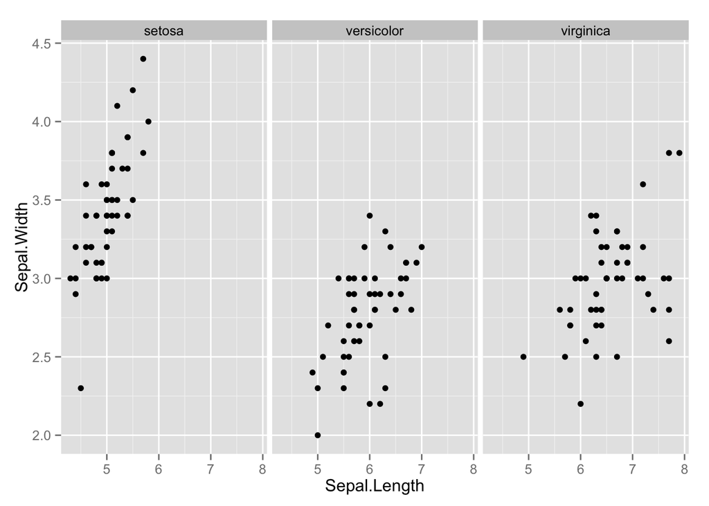

```r
ggplot(iris, aes(x=Sepal.Length,y=Sepal.Width))+geom_point()+facet_grid(.~Species)
```

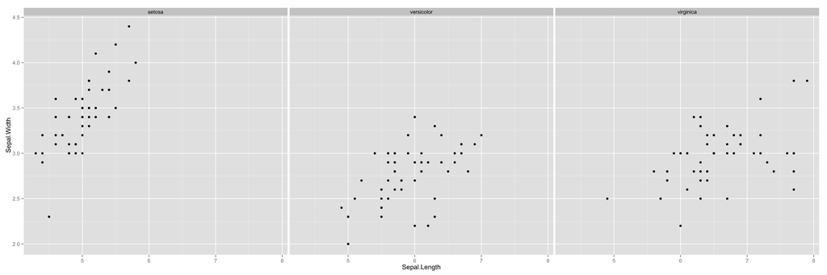

```r
ggplot(iris, aes(x=Sepal.Length,y=Sepal.Width))+geom_point()+facet_grid(.~Species)
```